# Problem Set 3

Due date: 25 September

Please upload your completed assignment to the ELMs course site (under the assignments menu) and to your class Github repository. You need to upload both your Quarto document (with R code, as needed) and its rendered output (either as a PDF or HTML file).

**Total points: 30**

```r
dem_wealth_df <- readr::read_csv("http://svmiller.com/extdata/democracy-income-1950.csv") |>
  dplyr::transmute(iso3c, country, gdp_per_cap = wbgdp2011est / wbpopest, democracy_score = xm_qudsest)
```

The `dem_wealth_df` data set (taken from the wonderful Dr Steven V Miller’s [blog post](https://svmiller.com/blog/2023/09/democracy-income-correlation-analysis/)) will help us explore the relationship between a country’s level of democracy and its citizens’ wealth in 1950. It is a replication of [Lipset (1959)](https://www.cambridge.org/core/journals/american-political-science-review/article/abs/some-social-requisites-of-democracy-economic-development-and-political-legitimacy1/26559429359F42D3E9B8BC82CA65546A). Miller uses Xavier Marquez’s [measure for democracy](https://www.cambridge.org/core/journals/political-analysis/article/democratic-compromise-a-latent-variable-analysis-of-ten-measures-of-regime-type/2A6B2BBA6F80367644F2C5007E1CFC29). This is a great (if complicated) measure. For this problem set, you only need to know that a country’s level of democracy increases with its “democracy score”.

## Question 1

### Part A

*Points: 2*

**Note**

2/2

> Using the `dem_wealth_df` data frame loaded in above, produce a scatter plot of the variables `democracy_score` and `gdp_per_cap` (with `gdp_per_cap` as the dependent variable on the y-axis). Professionally format your graph.

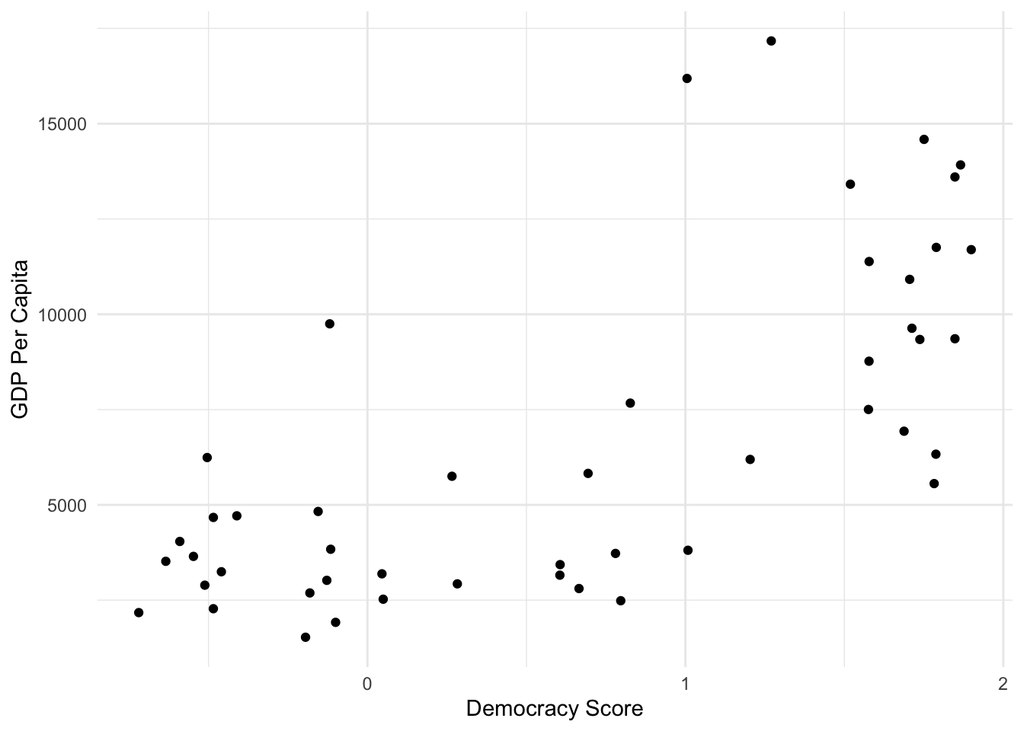

```r
library(ggplot2)
ggplot(dem_wealth_df, aes(x = democracy_score, y = gdp_per_cap)) +
  geom_point() +
  theme_minimal() +
  labs(x = "Democracy Score",
       y = "GDP Per Capita")
```

**Note**

Add an informative title next time.

### Part B

*Points: 3*

**Note**

3/3

> Describe the scatter plot. Note suspected outliers if any exist (a visual inspection will suffice for this question).

**Answer:** There is a general tendency for countries with higher democracy scores to have higher GDP per capita. One notable outlier is a case which has a negative democracy score but has a GDP per capital close to $10,000. Similarly, two cases with a democracy score around 1 have far higher GDP per capitas than expected.

## Question 2

*Points: 2*

**Note**

0/2

> Calculate the correlation coefficient between `democracy_score` and `gdp_per_cap`. What does it tell you about the relationship between a country’s level of democracy and its citizens’ wealth?

```r
m <- lm(democracy_score ~ gdp_per_cap, data = dem_wealth_df)

m
```

```
Call:
lm(formula = democracy_score ~ gdp_per_cap, data = dem_wealth_df)

Coefficients:
(Intercept)  gdp_per_cap
 -0.3415341    0.0001511
```

**Note**

You’re jumping ahead. Not the correlation coefficient (this is the regression coefficient).

Also, you needed to explain what the coefficient told us about the rel.

## Question 3

I would like to know whether individuals with higher levels of education tend to pay greater levels of attention to politics than those with lower levels of education.

### Part A

*Points: 5*

**Note**

5/5

> Using the `nes` data set in the `polisciols` R package, construct a cross-tab of the relationship between `attention_to_politics` and `education`. Focus only on those respondents who provided answers (filter out “Refused”, “Don’t know”, and missing responses).

```r
library(polisciols)
library(modelsummary)
library(tidyverse)

nes_filter <- polisciols::nes |>
   mutate(education = as.character(education),
         attention_to_politics = as.character(attention_to_politics)) |>
   filter(!education %in% c("Refused", "Don't know") & !is.na(education)) |>
   filter(!attention_to_politics %in% c("Refused", "Don't know") & !is.na(attention_to_politics)) |>
  mutate(education = factor(education,
                            levels = c("Less than high school credential",
                                       "High school credential",
                                       "Some post-high school, no bachelor’s degree",
                                       "Bachelor’s degree",
                                       "Graduate degree"))) |>
  mutate(attention_to_politics = factor(attention_to_politics,
                                        levels = c("Never",
                                                   "Some of the time",
                                                   "About half the time",
                                                   "Most of the time",
                                                   "Always")))

datasummary_crosstab(education ~ attention_to_politics, data = nes_filter)
```

| education |  | Never | Some of the time | About half the time | Most of the time | Always | All |
| --- | --- | --- | --- | --- | --- | --- | --- |
| Less than high school credential | N | 13 | 115 | 78 | 101 | 69 | 376 |
|  | % row | 3.5 | 30.6 | 20.7 | 26.9 | 18.4 | 100.0 |
| High school credential | N | 27 | 317 | 275 | 475 | 242 | 1336 |
|  | % row | 2.0 | 23.7 | 20.6 | 35.6 | 18.1 | 100.0 |
| Some post-high school, no bachelor’s degree | N | 25 | 458 | 597 | 1120 | 590 | 2790 |
|  | % row | 0.9 | 16.4 | 21.4 | 40.1 | 21.1 | 100.0 |
| Bachelor’s degree | N | 8 | 280 | 401 | 867 | 499 | 2055 |
|  | % row | 0.4 | 13.6 | 19.5 | 42.2 | 24.3 | 100.0 |
| Graduate degree | N | 4 | 171 | 215 | 689 | 512 | 1591 |
|  | % row | 0.3 | 10.7 | 13.5 | 43.3 | 32.2 | 100.0 |
| All | N | 77 | 1341 | 1566 | 3252 | 1912 | 8148 |
|  | % row | 0.9 | 16.5 | 19.2 | 39.9 | 23.5 | 100.0 |

### Part B

*Points: 3*

**Note**

2.75/3

> Describe the relationship between these two variables (if one exists).

**Answer:**

There were a few interesting relationships of note:

1. About 40% of all respondents indicated that they paid attention to politics most of the time, and this proportion of respondents steadily increases between each level.
2. Respondents with a high school credential and less than a high school credential had a tendency to pay attention to politics only some of the time at greater rates than some post-high school and above.
3. Respondents with a graduate degree answered that they always pay attention to politics at the highest rate (32.2%).
4. Respondents with less than a high school credential answered that they never pay attention to politics at the highest rate (3.5%). This relationship comes with the caveat that only 0.9% of all respondents answered “never.”

**Note**

But what is the overall relationship? Do people with higher levels of education tend to pay more attention to politics?

## Question 4

*Points: 5*

**Note**

5/5

I hypothesize that US voters who identify as being religious are less likely to support Federal government funding of scientific research. To test this, I run a survey of a representative sample of the US voting population. I ask respondents to indicate how often they attend religious ceremonies as a proxy measure of how strongly they identify as religious. They can answer: never, only for significant events, or regularly. Next, I ask respondents whether they think the Federal government’s funding of scientific research is “too little”, “about right”, or “too much”.

> Describe how you would construct a cross-tab to evaluate my hypothesis. Which responses (religious identification or support for Federal funding) would you compare within? Relatedly, which would you vary? Finally, what statistics would you use to make your comparisons?

**Answer**:

First, I would designate religious attendance as my Independent Variable and government funding as my Dependent Variable. This way I would be observing directly how religiosity affects perceptions on federal funding towards science.

To observe how religiosity affects perceptions on government funding, I would arrange the table so shows the number and proportion of respondents for each level of funding according to their religious attendance. If my hypothesis were to be true, I would see higher proportions of respondents who attend religious events regularly select “too much.”

## Question 5

Let’s return to our original question of the relationship between democracy and individuals’ wealth.

### Part A

*Points: 2*

**Note**

2/2

> Create two new variables based on a country’s level of democracy, and its citizens’ wealth. For the democracy variable, split countries into three categories: `autocracy` if they score in the lowest third of democracy scores, `hybrid` if they score in the middle third, and `democracy` if they score in the highest third. Similarly, for the wealth variable, split countries into three categories: `low income` if they score in the lowest third of GDP per capita, `middle income` if they score in the middle third, and `high income` if they score in the highest third.

```r
library(tidyverse)
DS_Quartile <- dem_wealth_df |>
  mutate(
    democracy_category = case_when(
      democracy_score <= quantile(democracy_score, 1/3, na.rm = TRUE) ~ "autocracy",
      democracy_score > quantile(democracy_score, 1/3, na.rm = TRUE) &
        democracy_score <= quantile(democracy_score, 2/3, na.rm = TRUE) ~ "hybrid",
      democracy_score > quantile(democracy_score, 2/3, na.rm = TRUE) ~ "democracy"
    ),
    wealth_category = case_when(
      gdp_per_cap <= quantile(gdp_per_cap, 1/3, na.rm = TRUE) ~ "low income",
      gdp_per_cap > quantile(gdp_per_cap, 1/3, na.rm = TRUE) &
        gdp_per_cap <= quantile(gdp_per_cap, 2/3, na.rm = TRUE) ~ "middle income",
      gdp_per_cap > quantile(gdp_per_cap, 2/3, na.rm = TRUE) ~ "high income"
    )
  )

DSQ_Scale <- DS_Quartile |>
  mutate(
    democracy_category = factor(democracy_category, levels = c("autocracy", "hybrid", "democracy")),
    wealth_category = factor(wealth_category, levels = c("low income", "middle income", "high income"))
  )
```

### Part B

*Points: 3*

**Note**

3/3

> Create a cross-tab.

```r
library(modelsummary)

datasummary_crosstab(
  democracy_category ~ wealth_category,
  data = DSQ_Scale
)
```

| democracy_category |  | low income | middle income | high income | All |
| --- | --- | --- | --- | --- | --- |
| autocracy | N | 8 | 7 | 1 | 16 |
|  | % row | 50.0 | 43.8 | 6.2 | 100.0 |
| hybrid | N | 8 | 5 | 3 | 16 |
|  | % row | 50.0 | 31.2 | 18.8 | 100.0 |
| democracy | N | 0 | 4 | 12 | 16 |
|  | % row | 0.0 | 25.0 | 75.0 | 100.0 |
| All | N | 16 | 16 | 16 | 48 |
|  | % row | 33.3 | 33.3 | 33.3 | 100.0 |

### Part C

*Points: 5*

**Note**

5/5

> Describe the relationship between these variables.

Most democracies tend to be high income, with a few in the middle income range.

Hybrid regimes are mostly clustered in the low income classification. However, there tends to be a more gradual decrease in proportion as income increases.

Around 94% of autocracies in the data set were in the middle- to low-income range, with half under the low income classification.

Overall, high-income countries tend to be democratic, while low-income countires seem to be split between hybrid and autocratic regimes. Middle income regimes appear to be mixed throughout, with a slight tendency towards autocracy and hybrid regimes, respectively.